# Exploratory Data Analysis

```python
#!pip install plotly
#!pip install cufflinks
#!pip install numpy
#!pip install pandas
#!pip install maplotlib
#!pip install seaborn
#!pip install showast
#!pip install DateTime
```

prepocessing step:

Firstly we drop some column like poster_ path,imdb_id,tagline,runtime,homepage because we do not really need thease column. After we have calculated top 10 profited movies respect to budget and revenue column Then we have calculated top 10 popular movies from popular column and then we sort most prefrable language for movies and plot them . We have used json shrinker because in movie dataset some columns are in json formate like gener and we want to do some analysis based On that so we need to extract genere from json thats why we have used this and after this we have plot budget and revenu based on each genere.

In Rating dataset first we drop duplicates and then we group top 10 movie and then get the title of movie from movie dataset from movie id and plot top 10 watched movies .

In Credit dataset there is information about cast and crew so firstly we convert id in integer and then we merge this on movie dataset . After we want to analysis that actor with highest revenue generated and also director so firstly we extract actor and director name from cast and crew column and then do calculation and plot them.

In keyword dataset we want to plot highest popluarity respect to keywords so in this dataset keyword is also in json array formate so first we parse json and ectract keyword and then find unique keywords and calculate no of occurrence for each keyword and then plot them.

In Rating dataset we have converted time stamp filed into year and month because it is usefull in analysis on rating over time. In link data set we have Identifiers that can be used to link to other sources of movie data are contained in the file links.csv. Each line of this file after the header row represents one movie, and has the following format:movieId,imdbId,tmdbId

So we merge link and rating on movie id and hekps do analysis on users rating on particular movieid.

next we did analysis on rating data set which we add 2 more coulmn year and month from timestamp column ,then we droped it. we did analsis on frequency of rating and average rating with time.

next we merge rating and movie dataset on movieid so we can get analysis of distrubution of user per year. then we did analysis on user and thier size its their occurance on different movie for rating

import all neccessary libraries

```python
# Inport all the imporatant library
import numpy as np
import pandas as pd
import os
import matplotlib.pyplot as plt
import seaborn as sns
%matplotlib inline
import string
import ast
from datetime import datetime
import plotly.offline as py
import plotly.express as px
import plotly.graph_objs as go
from plotly.offline import init_notebook_mode, iplot, plot
init_notebook_mode(connected=True)
```

# Movie_metadata Dataset

Preprocessing : checking missing value in data

Droping some column which are having less impact on our analysis and which do not want it

```python
import pandas as pd
missing_values = ['na','--','?','-','None','none','non']
movie_df = pd.read_csv('movies_metadata.csv', na_values=missing_values)
movie_df = movie_df.drop(columns=['poster_path', 'imdb_id', 'runtime', 'status', 'belongs_to_collection', 'homepage','tagline',
                                  'adult', 'overview', 'video', 'vote_average', 'vote_count','spoken_languages']).reset_index(drop=True)

movie_df.head()
```

|  | budget | genres | id | original_language | original_title | popularity | production_companies | production_countries | release_date | revenue | title |
| --- | --- | --- | --- | --- | --- | --- | --- | --- | --- | --- | --- |
| 0 | 30000000 | [{'id': 16, 'name': 'Animation'}, {'id': 35, '... | 862 | en | Toy Story | 21.9469 | [{'name': 'Pixar Animation Studios', 'id': 3}] | [{'iso_3166_1': 'US', 'name': 'United States o... | 1995-10-30 | 373554033.0 | Toy Story |
| 1 | 65000000 | [{'id': 12, 'name': 'Adventure'}, {'id': 14, '... | 8844 | en | Jumanji | 17.0155 | [{'name': 'TriStar Pictures', 'id': 559}, {'na... | [{'iso_3166_1': 'US', 'name': 'United States o... | 1995-12-15 | 262797249.0 | Jumanji |
| 2 | 0 | [{'id': 10749, 'name': 'Romance'}, {'id': 35, ... | 15602 | en | Grumpier Old Men | 11.7129 | [{'name': 'Warner Bros.', 'id': 6194}, {'name'... | [{'iso_3166_1': 'US', 'name': 'United States o... | 1995-12-22 | 0.0 | Grumpier Old Men |
| 3 | 16000000 | [{'id': 35, 'name': 'Comedy'}, {'id': 18, 'nam... | 31357 | en | Waiting to Exhale | 3.85949 | [{'name': 'Twentieth Century Fox Film Corporat... | [{'iso_3166_1': 'US', 'name': 'United States o... | 1995-12-22 | 81452156.0 | Waiting to Exhale |
| 4 | 0 | [{'id': 35, 'name': 'Comedy'}] | 11862 | en | Father of the Bride Part II | 8.38752 | [{'name': 'Sandollar Productions', 'id': 5842}... | [{'iso_3166_1': 'US', 'name': 'United States o... | 1995-02-10 | 76578911.0 | Father of the Bride Part II |

```python
movie_df.shape
```

```
(45466, 11)
```

drop coulmn which are not high co related to budget

```python
Profited_movies = movie_df.drop(columns=['genres', 'original_language', 'popularity', 'production_companies', 'production_countries',
                                  'release_date']).reset_index(drop=True)


Profited_movies['budget'] = pd.to_numeric(Profited_movies['budget'], errors = 'coerce')
# revenue is already a float
Profited_movies.loc[(Profited_movies['budget'] == 0) & (Profited_movies['revenue'] == 0), 'revenue'] = np.nan
Profited_movies.loc[Profited_movies['budget'] == 0, 'budget'] = np.nan

Profited_movies[Profited_movies['budget'] < 100]['budget'].count()
```

```
138
```

```python
def scale(num):
    if num < 100:
        return num * 1000000
    elif num >= 100 and num < 1000:
        return num * 1000
    else:
        return num

Profited_movies[['budget', 'revenue']] = Profited_movies[['budget', 'revenue']].applymap(scale)
```

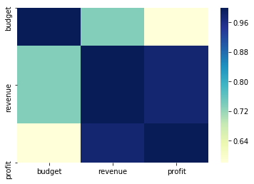

```python
Profited_movies['profit'] = Profited_movies['revenue'] - Profited_movies['budget']
sns.heatmap(Profited_movies.corr(), cmap = 'YlGnBu')
```

```python
Profited_movies.head(10)
```

[output not shown]

### Information-2: Top 10 most popular movies

retain column which is use full in popular movie analysis

```python
popular_movies = movie_df.drop(columns=['budget', 'original_language', 'production_companies', 'production_countries', 'release_date', 'revenue'
                                ]).reset_index(drop=True)
# Converted Object datatype into the Int datatype

popular_movies[popular_movies['popularity'].isnull()]
popular_movies['popularity'] = pd.to_numeric(popular_movies['popularity'], errors='coerce')
popular_movies = popular_movies.dropna(subset=['popularity'])
popular_movies['popularity'] = popular_movies['popularity'].astype(int)
print(popular_movies.dtypes)

Popular_movies = popular_movies.sort_values(by = 'popularity', axis=0, ascending=False, kind='quicksort', na_position='first')
Popular_movies.head(10)
```

```
genres            object
id                object
original_title    object
popularity         int32
title             object
dtype: object
```

|  | genres | id | original_title | popularity | title |
| --- | --- | --- | --- | --- | --- |
| 30700 | [{'id': 10751, 'name': 'Family'}, {'id': 16, '... | 211672 | Minions | 547 | Minions |
| 33356 | [{'id': 28, 'name': 'Action'}, {'id': 12, 'nam... | 297762 | Wonder Woman | 294 | Wonder Woman |
| 42222 | [{'id': 10751, 'name': 'Family'}, {'id': 14, '... | 321612 | Beauty and the Beast | 287 | Beauty and the Beast |
| 43644 | [{'id': 28, 'name': 'Action'}, {'id': 80, 'nam... | 339403 | Baby Driver | 228 | Baby Driver |
| 24455 | [{'id': 12, 'name': 'Adventure'}, {'id': 10751... | 177572 | Big Hero 6 | 213 | Big Hero 6 |
| 26564 | [{'id': 28, 'name': 'Action'}, {'id': 12, 'nam... | 293660 | Deadpool | 187 | Deadpool |
| 14551 | [{'id': 28, 'name': 'Action'}, {'id': 12, 'nam... | 19995 | Avatar | 185 | Avatar |
| 26566 | [{'id': 28, 'name': 'Action'}, {'id': 12, 'nam... | 283995 | Guardians of the Galaxy Vol. 2 | 185 | Guardians of the Galaxy Vol. 2 |
| 24351 | [{'id': 28, 'name': 'Action'}, {'id': 53, 'nam... | 245891 | John Wick | 183 | John Wick |
| 23675 | [{'id': 9648, 'name': 'Mystery'}, {'id': 53, '... | 210577 | Gone Girl | 154 | Gone Girl |

### Information-3: Top 10 preferable language

```
original_language
en    32269
fr     2438
it     1529
ja     1350
de     1080
es      994
ru      826
hi      508
ko      444
zh      409
dtype: int64
```

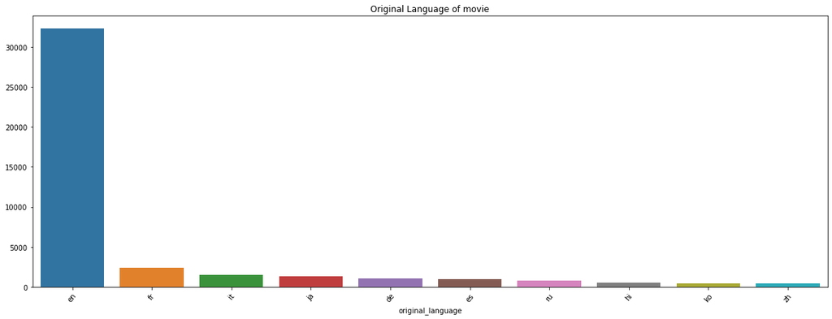

```python
plt.figure(figsize=(20,7))
movie_original_language = movie_df.groupby('original_language').size().sort_values(ascending=False)
top_10_highest_language_movie = movie_original_language.head(10)
print(top_10_highest_language_movie)
sns.barplot(top_10_highest_language_movie.index, top_10_highest_language_movie.values)
plt.title('Original Language of movie')
plt.xticks(rotation=50);
```

### Information-4: Which year has a highest release of movie?

```
release_date
2014.0    1974
dtype: int64
```

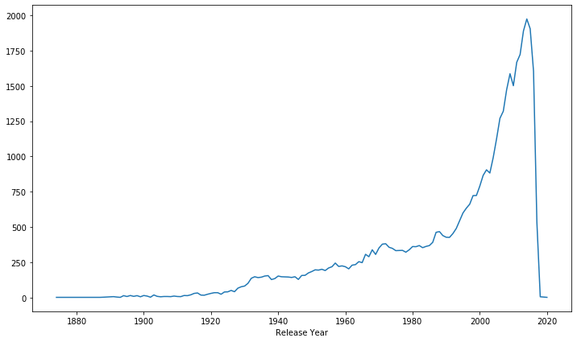

```python
movie_df['release_date'] = pd.to_datetime(movie_df['release_date'], errors='coerce')
movie_df['release_date'].dtypes

plt.figure(figsize=(12,7))
yearly_release_counts = movie_df.groupby(movie_df.release_date.dt.year).size().sort_values(ascending=False)
sns.lineplot(yearly_release_counts.index, yearly_release_counts.values);
plt.xlabel('Release Year')
print(yearly_release_counts.head(1))
```

### Information-5: Preferable weekday to release the movie

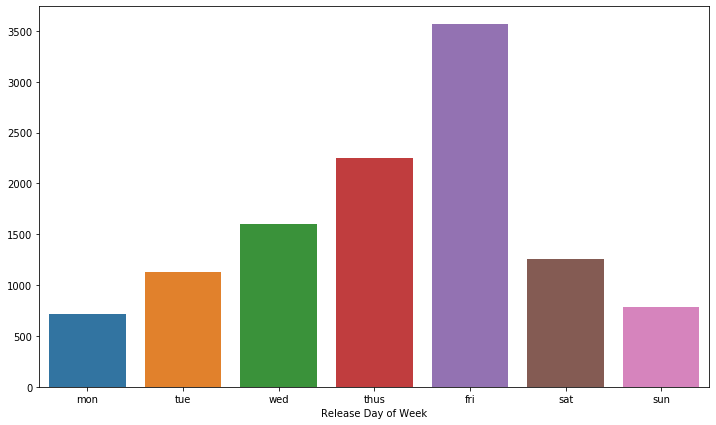

```python
plt.figure(figsize=(12,7))
weekday_release_counts = movie_df[movie_df.release_date.dt.year > 2010].groupby(movie_df.release_date.dt.dayofweek).size()
sns.barplot(['mon', 'tue', 'wed', 'thus', 'fri', 'sat', 'sun'], weekday_release_counts.values);
plt.xlabel('Release Day of Week')
```

# Ratings and ratings_small Dataset

### Information-6: Top 10 rated movies

```python
missing_values = ['na','--','?','-','None','none','non']
ratings_df = pd.read_csv('ratings.csv', na_values=missing_values)
ratings_small_df = pd.read_csv('ratings_small.csv', na_values=missing_values)
ratings_df.head()
```

|  | userId | movieId | rating | timestamp |
| --- | --- | --- | --- | --- |
| 0 | 1 | 110 | 1.0 | 1425941529 |
| 1 | 1 | 147 | 4.5 | 1425942435 |
| 2 | 1 | 858 | 5.0 | 1425941523 |
| 3 | 1 | 1221 | 5.0 | 1425941546 |
| 4 | 1 | 1246 | 5.0 | 1425941556 |

```python
ratings_small_df.head()
```

|  | userId | movieId | rating | timestamp |
| --- | --- | --- | --- | --- |
| 0 | 1 | 31 | 2.5 | 1260759144 |
| 1 | 1 | 1029 | 3.0 | 1260759179 |
| 2 | 1 | 1061 | 3.0 | 1260759182 |
| 3 | 1 | 1129 | 2.0 | 1260759185 |
| 4 | 1 | 1172 | 4.0 | 1260759205 |

```python
ratings_df =ratings_small_df.copy(deep=True)
ratings_df.drop_duplicates()
ratings_df.head()
```

|  | userId | movieId | rating | timestamp |
| --- | --- | --- | --- | --- |
| 0 | 1 | 31 | 2.5 | 1260759144 |
| 1 | 1 | 1029 | 3.0 | 1260759179 |
| 2 | 1 | 1061 | 3.0 | 1260759182 |
| 3 | 1 | 1129 | 2.0 | 1260759185 |
| 4 | 1 | 1172 | 4.0 | 1260759205 |

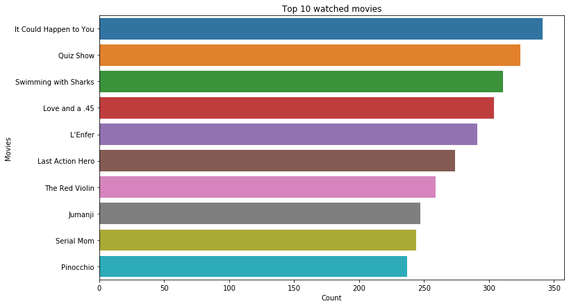

```python
def draw_horizontal_movie_bar(movie_titles, ratings_count, title=''):
    plt.figure(figsize=(12, 7))
    sns.barplot(y=movie_titles, x=ratings_count, orient='h')
    plt.title(title)
    plt.ylabel('Movies')
    plt.xlabel('Count')
    plt.show()

top_ten_rated_movies = ratings_df.groupby('movieId').size().sort_values(ascending=False)[:10]
top_ten_movie_titles = movie_df.iloc[top_ten_rated_movies.index].title

draw_horizontal_movie_bar(top_ten_movie_titles.values, top_ten_rated_movies.values, 'Top 10 watched movies')
```

### Information-7: Data of Production Counties

```python
movie_df['production_countries'] = movie_df['production_countries'].fillna('[]').apply(ast.literal_eval)
movie_df['production_countries'] = movie_df['production_countries'].apply(lambda x: [i['name'] for i in x] if isinstance(x, list) else [])
```

```python
s = movie_df.apply(lambda x: pd.Series(x['production_countries']),axis=1).stack().reset_index(level=1, drop=True)
s.name = 'countries'
```

```python
con_df = movie_df.drop('production_countries', axis=1).join(s)
con_df = pd.DataFrame(con_df['countries'].value_counts())
con_df['country'] = con_df.index
con_df.columns = ['num_movies', 'country']
con_df = con_df.reset_index().drop('index', axis=1)
con_df.head(10)
con_df = con_df[con_df['country'] != 'United States of America']
```

```python
data = [ dict(
        type = 'choropleth',
        locations = con_df['country'],
        locationmode = 'country names',
        z = con_df['num_movies'],
        text = con_df['country'],
        colorscale = [[0,'rgb(255, 255, 255)'],[1,'rgb(0, 255, 0)']],
        autocolorscale = False,
        reversescale = False,
        marker = dict(
            line = dict (
                color = 'rgb(180,180,180)',
                width = 0.5
            ) ),
    colorbar = dict(
            autotick = False,
            tickprefix = '',
            title = 'Production Countries'),
      ) ]

layout = dict(
    title = 'Production Countries for the MovieLens Movies (Apart from US)',
    geo = dict(
        showframe = False,
        showcoastlines = False,
        projection = dict(
            type = 'Mercator'
        )
    )
)

fig = dict( data=data, layout=layout )
py.iplot( fig, validate=False, filename='d3-world-map' )
```

[interactive chart not shown]

```python
column_changes = ['production_companies', 'production_countries', 'genres']

json_shrinker_dict = dict({'production_companies': list(), 'production_countries': list(), 'genres': list()})
movie_df.dropna(inplace=True)
```

```python
#Parsing JSONs for Extracting genres and production companies

for col in column_changes:
    if col == 'production_companies':
        for i in movie_df[col]:
            i = ast.literal_eval(i)
            if len(i) < 1:
                json_shrinker_dict['production_companies'].append(None)

            for element in i:
                json_shrinker_dict['production_companies'].append(element['name'])
                break
    elif col == 'production_countries':
        for i in movie_df[col]:
            i = ast.literal_eval(i)
            if len(i) < 1:
                json_shrinker_dict['production_countries'].append(None)
            for element in i:
                json_shrinker_dict['production_countries'].append(element['iso_3166_1'])
                break
    else:
        for i in movie_df[col]:
            i = ast.literal_eval(i)
            if len(i) < 1:
                json_shrinker_dict['genres'].append(None)

            for element in i:
                json_shrinker_dict['genres'].append(element['name'])
                break

for i in column_changes:
    movie_df[i] = json_shrinker_dict[i]

movie_df.dropna(inplace=True)

movie_df['budget'] = movie_df['budget'].astype(int)
```

```python
movie_df.head()
```

|  | budget | genres | id | original_language | original_title | popularity | production_companies | production_countries | release_date | revenue | title |
| --- | --- | --- | --- | --- | --- | --- | --- | --- | --- | --- | --- |
| 0 | 30000000 | Animation | 862 | en | Toy Story | 21.9469 | Pixar Animation Studios | US | 1995-10-30 | 373554033.0 | Toy Story |
| 1 | 65000000 | Adventure | 8844 | en | Jumanji | 17.0155 | TriStar Pictures | US | 1995-12-15 | 262797249.0 | Jumanji |
| 2 | 0 | Romance | 15602 | en | Grumpier Old Men | 11.7129 | Warner Bros. | US | 1995-12-22 | 0.0 | Grumpier Old Men |
| 3 | 16000000 | Comedy | 31357 | en | Waiting to Exhale | 3.85949 | Twentieth Century Fox Film Corporation | US | 1995-12-22 | 81452156.0 | Waiting to Exhale |
| 4 | 0 | Comedy | 11862 | en | Father of the Bride Part II | 8.38752 | Sandollar Productions | US | 1995-02-10 | 76578911.0 | Father of the Bride Part II |

```python
fig = px.scatter(movie_df, x='budget', y='revenue', hover_data=['title'], color='genres', width=800, height=800)
fig.update_layout(
    title='The Relationship between Budget and Revenue',
    xaxis_title='Budget',
    yaxis_title='Revenue',
    font=dict(
        size=16
    )
)
iplot(fig)
```

[interactive chart not shown]

### Information-8: Calculate movie budget according genere

```python
genre_budget_df = movie_df.groupby(['genres'])['budget'].sum()

fig = go.Figure([
    go.Bar(
        x=genre_budget_df.index,
        y=genre_budget_df.values,
        text=genre_budget_df.values,
        textposition='auto',
        marker_color=['#94447f',
                      '#5796ef',
                      '#8a59c0',
                      '#288abf',
                      '#0ab78d',
                      '#4ed993',
                      '#7d3970',
                      '#b3dc67',
                      '#dc560a',
                      '#0079fe',
                      '#98d3a8',
                      '#d5105a',
                      '#d04dcf',
                      '#58c7a2',
                      '#7bf1f8',
                      '#244155',
                      '#587b77',
                      '#c64ac2',
                      '#5e805d',
                      '#ebab95']
    )])

fig.update_layout(
    title='Sum of all Movie Budgets in each Genre',
    xaxis_title='Genre',
    yaxis_title='Total Budget',
    width=800,
    height=1000,
    font=dict(
        size=16
    )
)

fig.layout.template = 'seaborn'

iplot(fig)
```

[interactive chart not shown]

# Cast and Crew Dataset

```python
credits_df = pd.read_csv('credits.csv')
credits_df.head()
```

|  | cast | crew | id |
| --- | --- | --- | --- |
| 0 | [{'cast_id': 14, 'character': 'Woody (voice)',... | [{'credit_id': '52fe4284c3a36847f8024f49', 'de... | 862 |
| 1 | [{'cast_id': 1, 'character': 'Alan Parrish', '... | [{'credit_id': '52fe44bfc3a36847f80a7cd1', 'de... | 8844 |
| 2 | [{'cast_id': 2, 'character': 'Max Goldman', 'c... | [{'credit_id': '52fe466a9251416c75077a89', 'de... | 15602 |
| 3 | [{'cast_id': 1, 'character': "Savannah 'Vannah... | [{'credit_id': '52fe44779251416c91011acb', 'de... | 31357 |
| 4 | [{'cast_id': 1, 'character': 'George Banks', '... | [{'credit_id': '52fe44959251416c75039ed7', 'de... | 11862 |

```python
#conversion id to integer
def convert_int(x):
    try:
        return int(x)
    except:
        return np.nan
```

```python
movie_df['id'] = movie_df['id'].apply(convert_int)
```

```python
# merge credit to movie
movie_df['id'] = movie_df['id'].astype('int')
movie_df = movie_df.merge(credits_df, on='id')

movie_df.head()
```

|  | budget | genres | id | original_language | original_title | popularity | production_companies | production_countries | release_date | revenue | title | cast | crew |
| --- | --- | --- | --- | --- | --- | --- | --- | --- | --- | --- | --- | --- | --- |
| 0 | 30000000 | Animation | 862 | en | Toy Story | 21.9469 | Pixar Animation Studios | US | 1995-10-30 | 373554033.0 | Toy Story | [{'cast_id': 14, 'character': 'Woody (voice)',... | [{'credit_id': '52fe4284c3a36847f8024f49', 'de... |
| 1 | 65000000 | Adventure | 8844 | en | Jumanji | 17.0155 | TriStar Pictures | US | 1995-12-15 | 262797249.0 | Jumanji | [{'cast_id': 1, 'character': 'Alan Parrish', '... | [{'credit_id': '52fe44bfc3a36847f80a7cd1', 'de... |
| 2 | 0 | Romance | 15602 | en | Grumpier Old Men | 11.7129 | Warner Bros. | US | 1995-12-22 | 0.0 | Grumpier Old Men | [{'cast_id': 2, 'character': 'Max Goldman', 'c... | [{'credit_id': '52fe466a9251416c75077a89', 'de... |
| 3 | 16000000 | Comedy | 31357 | en | Waiting to Exhale | 3.85949 | Twentieth Century Fox Film Corporation | US | 1995-12-22 | 81452156.0 | Waiting to Exhale | [{'cast_id': 1, 'character': "Savannah 'Vannah... | [{'credit_id': '52fe44779251416c91011acb', 'de... |
| 4 | 0 | Comedy | 11862 | en | Father of the Bride Part II | 8.38752 | Sandollar Productions | US | 1995-02-10 | 76578911.0 | Father of the Bride Part II | [{'cast_id': 1, 'character': 'George Banks', '... | [{'credit_id': '52fe44959251416c75039ed7', 'de... |

```python
movie_df['cast'] = movie_df['cast'].apply(ast.literal_eval)
movie_df['crew'] = movie_df['crew'].apply(ast.literal_eval)
```

```python
movie_df['cast_size'] = movie_df['cast'].apply(lambda x: len(x))
movie_df['crew_size'] = movie_df['crew'].apply(lambda x: len(x))
```

```python
movie_df['cast'] = movie_df['cast'].apply(lambda x: [i['name'] for i in x] if isinstance(x, list) else [])
```

```python
# Get director from column
def get_director(x):
    for i in x:
        if i['job'] == 'Director':
            return i['name']
    return np.nan
```

```python
movie_df['director'] = movie_df['crew'].apply(get_director)
```

```python
s = movie_df.apply(lambda x: pd.Series(x['cast']),axis=1).stack().reset_index(level=1, drop=True)
s.name = 'actor'
cast_df = movie_df.drop('cast', axis=1).join(s)
```

### Information-9: Actor with higest revenu

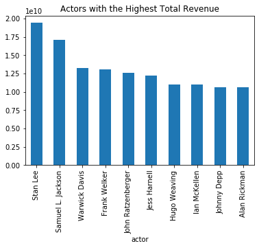

```python
plt.title('Actors with the Highest Total Revenue')
cast_df.groupby('actor')['revenue'].sum().sort_values(ascending=False).head(10).plot(kind='bar')
plt.show()
```

### Information-10: Directors with the Highest Revenue

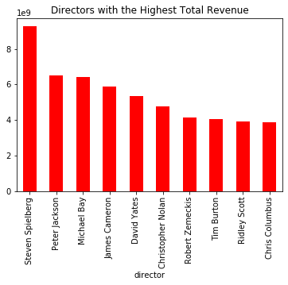

```python
plt.title('Directors with the Highest Total Revenue')
movie_df.groupby('director')['revenue'].sum().sort_values(ascending=False).head(10).plot(kind='bar', colormap='autumn')
plt.show()
```

# Keyword Dataset

```python
keywords = pd.read_csv('keywords.csv')
keywords.head(5)
```

|  | id | keywords |
| --- | --- | --- |
| 0 | 862 | [{'id': 931, 'name': 'jealousy'}, {'id': 4290,... |
| 1 | 8844 | [{'id': 10090, 'name': 'board game'}, {'id': 1... |
| 2 | 15602 | [{'id': 1495, 'name': 'fishing'}, {'id': 12392... |
| 3 | 31357 | [{'id': 818, 'name': 'based on novel'}, {'id':... |
| 4 | 11862 | [{'id': 1009, 'name': 'baby'}, {'id': 1599, 'n... |

```python
#  Extract keywords From Json Array

def clean_sentence(s, concat=None):
    s = s.translate(str.maketrans('', '', string.punctuation))
    s = s.lower()
    if concat:
        s = concat.join(s.split())
    return s
```

```python
# Extract keywords From Json Array


keywords_len = len(keywords)
keywords_dict = {}
keywords_id_dict = {}

for it in range(keywords_len):
    keywords_arr = keywords.iloc[it]['keywords']
    keywords_arr = eval(keywords_arr)
    keywords_id_dict[keywords.iloc[it]['id']]=""
    for iit in range(len(keywords_arr)):
        keywords_id_dict[keywords.iloc[it]['id']] = keywords_id_dict[keywords.iloc[it]['id']] + clean_sentence(keywords_arr[iit]['name']) + " "
        if keywords_dict.get(keywords_arr[iit]['name']):
            keywords_dict[keywords_arr[iit]['name']] = keywords_dict[keywords_arr[iit]['name']]+1
        else:
            keywords_dict[keywords_arr[iit]['name']]=1
```

```python
keyword_occurences = []
for k,v in keywords_dict.items():
    keyword_occurences.append([k,v])
keyword_occurences.sort(key = lambda x:x[1], reverse = True)
```

### Information-11: Keyword Wise popularity plot

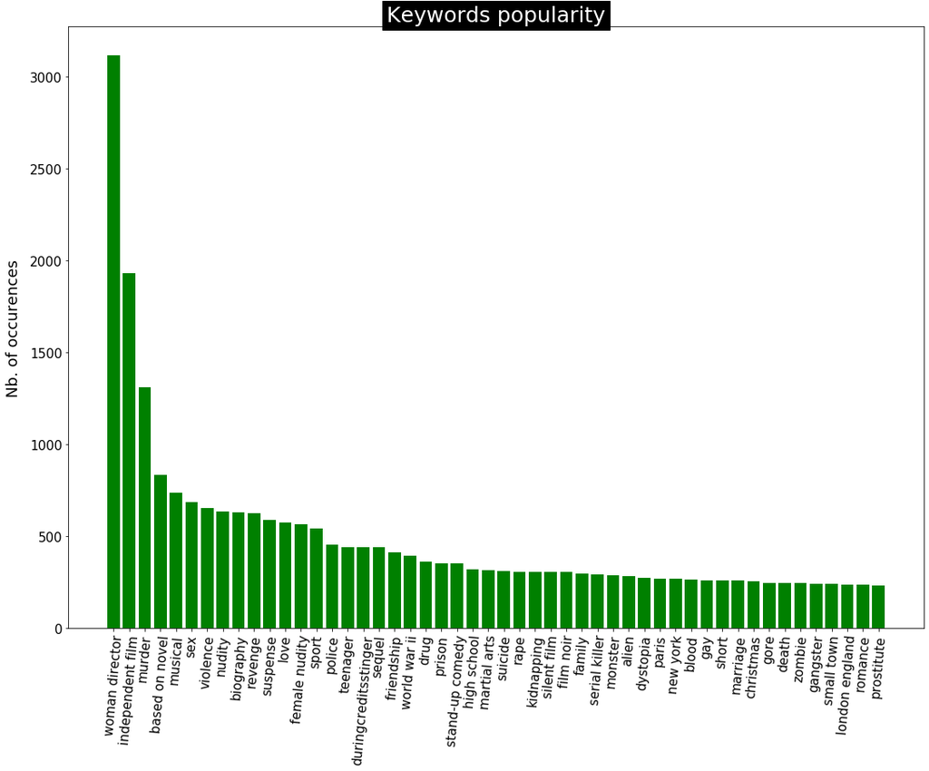

```python
fig = plt.figure(1, figsize=(18,13))
ax = fig.add_subplot(1,1,1)
trunc_occurences = keyword_occurences[0:50]
y_axis = [i[1] for i in trunc_occurences]
x_axis = [k for k,i in enumerate(trunc_occurences)]
x_label = [i[0] for i in trunc_occurences]
plt.xticks(rotation=85, fontsize = 15)
plt.yticks(fontsize = 15)
plt.xticks(x_axis, x_label)
plt.ylabel("Nb. of occurences", fontsize = 18, labelpad = 10)
ax.bar(x_axis, y_axis, align = 'center', color='g')
#_______________________
plt.title("Keywords popularity",bbox={'facecolor':'k', 'pad':5},color='w',fontsize = 25)
plt.show()
```

# links dataset

```python
missing_values = ['na','--','?','-','None','none','non','NaN']
link_df = pd.read_csv('links.csv', na_values=missing_values)
missing_values = ['na','--','?','-','None','none','non','NaN']
link_df = pd.read_csv('links.csv', na_values=missing_values)
link_df.head(5)
```

|  | movieId | imdbId | tmdbId |
| --- | --- | --- | --- |
| 0 | 1 | 114709 | 862.0 |
| 1 | 2 | 113497 | 8844.0 |
| 2 | 3 | 113228 | 15602.0 |
| 3 | 4 | 114885 | 31357.0 |
| 4 | 5 | 113041 | 11862.0 |

```python
missing_values = ['na','--','?','-','None','none','non','NaN']
ratings_df = pd.read_csv('ratings.csv', na_values=missing_values)
link_rating = link_df.merge(ratings_df, on='movieId')
link_rating.head()
```

|  | movieId | imdbId | tmdbId | userId | rating | timestamp |
| --- | --- | --- | --- | --- | --- | --- |
| 0 | 1 | 114709 | 862.0 | 8 | 4.0 | 1013443596 |
| 1 | 1 | 114709 | 862.0 | 9 | 4.5 | 1073837180 |
| 2 | 1 | 114709 | 862.0 | 12 | 4.0 | 943912205 |
| 3 | 1 | 114709 | 862.0 | 20 | 4.0 | 1368361348 |
| 4 | 1 | 114709 | 862.0 | 24 | 4.0 | 979869938 |

```python
from datetime import datetime

link_rating['timestamp'] = link_rating['timestamp'].apply(datetime.fromtimestamp)
link_rating['year'] = link_rating['timestamp'].dt.year
link_rating['month'] = link_rating['timestamp'].dt.month
link_rating = link_rating.sort_values('timestamp')
print('First 5:')
display(ratings_df.head())
print()
print('Last 5:')
display(ratings_df.tail())
```

```
First 5:
```

|  | userId | movieId | rating | timestamp |
| --- | --- | --- | --- | --- |
| 0 | 1 | 110 | 1.0 | 1425941529 |
| 1 | 1 | 147 | 4.5 | 1425942435 |
| 2 | 1 | 858 | 5.0 | 1425941523 |
| 3 | 1 | 1221 | 5.0 | 1425941546 |
| 4 | 1 | 1246 | 5.0 | 1425941556 |

```
Last 5:
```

|  | userId | movieId | rating | timestamp |
| --- | --- | --- | --- | --- |
| 26024284 | 270896 | 58559 | 5.0 | 1257031564 |
| 26024285 | 270896 | 60069 | 5.0 | 1257032032 |
| 26024286 | 270896 | 63082 | 4.5 | 1257031764 |
| 26024287 | 270896 | 64957 | 4.5 | 1257033990 |
| 26024288 | 270896 | 71878 | 2.0 | 1257031858 |

```python
link_rating.drop_duplicates()
link_rating.describe()
```

|  | movieId | imdbId | tmdbId | userId | rating | year | month |
| --- | --- | --- | --- | --- | --- | --- | --- |
| count | 2.602429e+07 | 2.602429e+07 | 2.601079e+07 | 2.602429e+07 | 2.602429e+07 | 2.602429e+07 | 2.602429e+07 |
| mean | 1.584911e+04 | 2.953950e+05 | 1.602270e+04 | 1.350371e+05 | 3.528090e+00 | 2.006612e+03 | 6.565969e+00 |
| std | 3.108526e+04 | 5.068961e+05 | 4.158878e+04 | 7.817620e+04 | 1.065443e+00 | 6.536728e+00 | 3.510570e+00 |
| min | 1.000000e+00 | 1.000000e+00 | 2.000000e+00 | 1.000000e+00 | 5.000000e-01 | 1.995000e+03 | 1.000000e+00 |
| 25% | 1.073000e+03 | 9.742800e+04 | 6.750000e+02 | 6.716400e+04 | 3.000000e+00 | 2.001000e+03 | 3.000000e+00 |
| 50% | 2.583000e+03 | 1.162610e+05 | 5.259000e+03 | 1.351630e+05 | 3.500000e+00 | 2.006000e+03 | 7.000000e+00 |
| 75% | 6.503000e+03 | 2.573600e+05 | 1.135900e+04 | 2.026930e+05 | 4.000000e+00 | 2.013000e+03 | 1.000000e+01 |
| max | 1.762750e+05 | 7.158814e+06 | 4.691720e+05 | 2.708960e+05 | 5.000000e+00 | 2.017000e+03 | 1.200000e+01 |

### Information-12: The user ratings for the movie_id == 1

```python
movie_1 = link_rating[link_rating.movieId == 1]
movie_1.head(5)
```

|  | movieId | imdbId | tmdbId | userId | rating | timestamp | year | month |
| --- | --- | --- | --- | --- | --- | --- | --- | --- |
| 30851 | 1 | 114709 | 862.0 | 126622 | 4.0 | 1996-01-29 01:00:00 | 1996 | 1 |
| 26828 | 1 | 114709 | 862.0 | 109682 | 4.0 | 1996-01-30 00:54:20 | 1996 | 1 |
| 23337 | 1 | 114709 | 862.0 | 95351 | 5.0 | 1996-02-01 15:33:23 | 1996 | 2 |
| 49440 | 1 | 114709 | 862.0 | 202478 | 5.0 | 1996-02-01 20:48:55 | 1996 | 2 |
| 52992 | 1 | 114709 | 862.0 | 217112 | 4.0 | 1996-02-02 11:01:54 | 1996 | 2 |

```python
movie_1.groupby('rating').size()
movi1_1_data = movie_1.groupby('rating')
movi1_1_data.agg({'rating':'mean'})
```

| rating | rating |
| --- | --- |
| 0.5 | 0.5 |
| 1.0 | 1.0 |
| 1.5 | 1.5 |
| 2.0 | 2.0 |
| 2.5 | 2.5 |
| 3.0 | 3.0 |
| 3.5 | 3.5 |
| 4.0 | 4.0 |
| 4.5 | 4.5 |
| 5.0 | 5.0 |

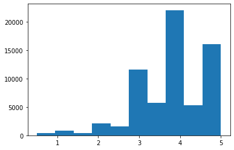

```python
plt.hist(x=movie_1['rating'] )
plt.show()
```

### Information-12: Rating frequency of each rating types

```python
ratings_df.drop_duplicates()
ratings_df['timestamp'] = ratings_df['timestamp'].apply(datetime.fromtimestamp)
ratings_df['year'] = ratings_df['timestamp'].dt.year
ratings_df['month'] = ratings_df['timestamp'].dt.month
ratings_df = ratings_df.sort_values('timestamp')
print('First 5:')
display(ratings_df.head())
print()
print('Last 5:')
display(ratings_df.tail())
```

```
First 5:
```

|  | userId | movieId | rating | timestamp | year | month |
| --- | --- | --- | --- | --- | --- | --- |
| 3662481 | 38150 | 1176 | 4.0 | 1995-01-09 12:46:44 | 1995 | 1 |
| 4313954 | 44717 | 1079 | 3.0 | 1995-01-09 12:46:49 | 1995 | 1 |
| 4313911 | 44717 | 47 | 5.0 | 1995-01-09 12:46:49 | 1995 | 1 |
| 4313905 | 44717 | 21 | 3.0 | 1995-01-09 12:46:49 | 1995 | 1 |
| 18389348 | 190860 | 21 | 5.0 | 1996-01-29 01:00:00 | 1996 | 1 |

```
Last 5:
```

|  | userId | movieId | rating | timestamp | year | month |
| --- | --- | --- | --- | --- | --- | --- |
| 8285608 | 85434 | 3210 | 2.0 | 2017-08-04 08:38:59 | 2017 | 8 |
| 8286269 | 85434 | 82169 | 3.0 | 2017-08-04 08:39:06 | 2017 | 8 |
| 8285257 | 85434 | 1013 | 4.0 | 2017-08-04 08:41:23 | 2017 | 8 |
| 19224356 | 199634 | 60040 | 3.0 | 2017-08-04 08:53:43 | 2017 | 8 |
| 17280641 | 179412 | 167786 | 3.5 | 2017-08-04 08:57:50 | 2017 | 8 |

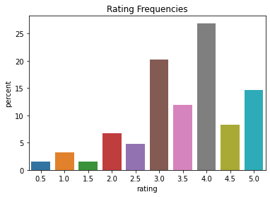

```python
norm_counts = (
    ratings_df['rating']
    .value_counts(normalize=True, sort=False)
    .multiply(100)
    .reset_index()
    .rename(columns={'rating': 'percent', 'index': 'rating'})
)
ax = sns.barplot(x='rating', y='percent', data=norm_counts)
ax.set_title('Rating Frequencies')
plt.show()
```

### Information-13: Ratings submitted per month

```python
month_counts = ratings_df[['year', 'month', 'rating']].groupby(['year', 'month']).count()
month_counts = month_counts.rename(index=str, columns={'rating': 'of_Ratings'})
month_counts = month_counts.reset_index()
month_counts['Date'] = month_counts[['year', 'month']].apply(
    lambda x: datetime(year=int(x[0]), month=int(x[1]), day=1), axis=1
)
month_counts = month_counts.set_index('Date', drop=True)
display(month_counts)
```

| Date | year | month | of_Ratings |
| --- | --- | --- | --- |
| 1995-01-01 | 1995 | 1 | 4 |
| 1996-01-01 | 1996 | 1 | 66 |
| 1996-02-01 | 1996 | 2 | 588 |
| 1996-03-01 | 1996 | 3 | 10748 |
| 1996-04-01 | 1996 | 4 | 58825 |
| ... | ... | ... | ... |
| 2017-04-01 | 2017 | 4 | 149999 |
| 2017-05-01 | 2017 | 5 | 206998 |
| 2017-06-01 | 2017 | 6 | 150953 |
| 2017-07-01 | 2017 | 7 | 192921 |
| 2017-08-01 | 2017 | 8 | 13357 |

260 rows × 3 columns

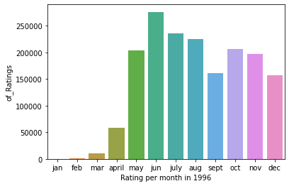

```python
%matplotlib inline
from datetime import datetime
from IPython.display import Markdown
from os.path import join
from os.path import exists
import matplotlib.pyplot as plt
import numpy as np
import pandas as pd
import seaborn as sns



a= month_counts[(month_counts["year"] == '1996' )]
sns.barplot(['jan', 'feb', 'mar', 'april', 'may', 'jun', 'july', 'aug', 'sept', 'oct', 'nov', 'dec'], a.of_Ratings)
plt.xlabel('Rating per month in 1996')
```

### Information-14: The average ratings over time or period

```python
month_counts = ratings_df.groupby(['year', 'month'])['rating'].agg([np.mean, np.std])
month_counts = month_counts.rename(index=str, columns={'mean': 'Rating'})
month_counts = month_counts.reset_index()
month_counts['Date'] = month_counts[['year', 'month']].apply(
    lambda x: datetime(year=int(x[0]), month=int(x[1]), day=1), axis=1
)
month_counts = month_counts.set_index('Date', drop=True)
display(month_counts)
```

| Date | year | month | Rating | std |
| --- | --- | --- | --- | --- |
| 1995-01-01 | 1995 | 1 | 3.750000 | 0.957427 |
| 1996-01-01 | 1996 | 1 | 3.984848 | 1.270886 |
| 1996-02-01 | 1996 | 2 | 3.739796 | 1.282292 |
| 1996-03-01 | 1996 | 3 | 3.943338 | 1.047956 |
| 1996-04-01 | 1996 | 4 | 3.805967 | 1.044333 |
| ... | ... | ... | ... | ... |
| 2017-04-01 | 2017 | 4 | 3.609374 | 1.075135 |
| 2017-05-01 | 2017 | 5 | 3.581286 | 1.040934 |
| 2017-06-01 | 2017 | 6 | 3.521642 | 1.071461 |
| 2017-07-01 | 2017 | 7 | 3.558550 | 1.076326 |
| 2017-08-01 | 2017 | 8 | 3.678708 | 1.057264 |

260 rows × 4 columns

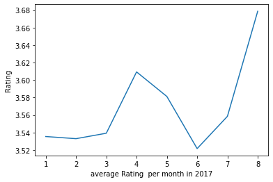

```python
b= month_counts[(month_counts["year"] == '2017' )]
sns.lineplot(b.month, b.Rating)
plt.xlabel('average Rating  per month in 2017')
```

### Information-15: Distribution of unique users as per year

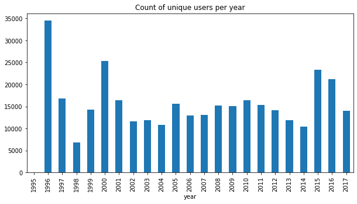

```python
ratings_df[['year', 'userId']].groupby(['year'])['userId'].nunique().plot.bar(x='year', y='user_id', title='Count of unique users per year', figsize=(10, 5));
```

### Information-16: The merged dataset rating and movie so can defined each user and thier size

here id , genres and title is nesccesry for analysis.

drop timestamp in rating.

```python
movie_df_small = movie_df[["id","genres","original_title"]]
ratings_df_small = ratings_df.rename(columns={'movieId': 'id'})
```

```python
def convert_int(x):
    try:
        return int(x)
    except:
        return np.nan
movie_df_small['id'] = movie_df_small['id'].apply(convert_int)
ratings_df_small['id'] = ratings_df_small['id'].apply(convert_int)
```

```python
dataF = pd.merge(movie_df_small,ratings_df_small, on = 'id',how = 'inner')
dataF = dataF.drop('timestamp',axis = 1)
dataF.head(1)
```

[output not shown]

```python
rating_user = dataF.groupby('userId').agg([np.mean,np.size])
rating_user_small  =rating_user[["rating"]]
rating_user_small
```

| userId | rating mean | rating size |
| --- | --- | --- |
| 1 | 4.045455 | 11.0 |
| 2 | 3.235294 | 17.0 |
| 3 | 3.125000 | 8.0 |
| 4 | 3.652174 | 23.0 |
| 5 | 4.200000 | 10.0 |
| ... | ... | ... |
| 270892 | 3.552632 | 38.0 |
| 270893 | 3.402439 | 82.0 |
| 270894 | 2.560345 | 58.0 |
| 270895 | 4.235294 | 17.0 |
| 270896 | 3.965649 | 131.0 |

265917 rows × 2 columns

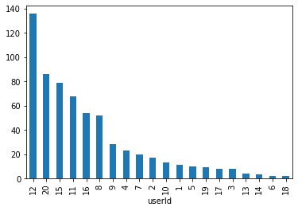

```python
rating_user_small['rating']['size'].head(20).sort_values(ascending = False).plot(kind = 'bar')
```